# Rticles: Scientific Documents with Bookdown R Package

www.lozanoisla.com

Jimmy Gomez $^{1}$, Flavio Lozano-Isla $^{2*}$

$^{1}$ Agronomist, Co-founder ww.quipo.org

$^{2}$ Agronomist MSc, email: flavjack@gmail.com

03 Jul. 2020 00:11:01

# Abstract

Class aptent taciti sociosqu ad litora torquent per conubia nostra, per inceptos himenaeos. Curabitur sodales ligula in libero. Sed dignissim lacinia nunc. Curabitur tortor. Pellentesque nibh. Aenean quam. In scelerisque sem at dolor. Maecenas mattis. Sed convallis tristique sem. Proin ut ligula vel nunc egestas porttitor. Morbi lectus risus, iaculis vel, suscipit quis, luctus non, massa. Fusce ac turpis quis ligula lacinia aliquet. Mauris ipsum. Nulla metus metus, ullamcorper vel, tincidunt sed, euismod in, nibh. Quisque volutpat condimentum velit. Class aptent taciti sociosqu ad litora torquent per conubia nostra, per inceptos himenaeos. Nam nec ante. Sed lacinia, urna non tincidunt mattis, tortor neque adipiscing diam, a cursus ipsum ante quis turpis. *Nulla facilisi* Ut fringilla. **Suspendisse potenti** Nunc feugiat mi a tellus consequat imperdiet. Vestibulum sapien. Proin quam. Etiam ultrices. Suspendisse in justo eu magna luctus suscipit. Sed lectus. Integer euismod lacus luctus magna. Quisque cursus, metus vitae pharetra auctor, sem massa mattis sem, at interdum magna augue eget diam.

**KeyWords:** Lorem, ipsum, dolor, sit amet, consectetur.

# 1 Introduction

Lorem ipsum Lozano-Isla et al. (2018) dolor sit amet, consectetur adipiscing elit. Integer nec odio. Praesent libero. Sed cursus ante dapibus diam. Sed nisi. Nulla quis sem at nibh elementum imperdiet. Duis sagittis ipsum. Praesent mauris Fusce nec tellus sed augue semper porta. Mauris massa. Vestibulum lacinia arcu eget nulla Class aptent taciti sociosqu ad litora torquent per conubia nostra, per inceptos himenaeos. Curabitur sodales ligula in libero. Sed dignissim lacinia nunc (Maluszynski et al., 2009; Pompelli et al., 2012).

Curabitur tortor (Avenot et al., 2009; Zárate & Gianina, 2017) Pellentesque nibh. Aenean quam. In scelerisque sem at dolor. Maecenas mattis. Sed convallis tristique sem. Proin ut ligula vel nunc egestas porttitor. Morbi lectus risus, iaculis vel, suscipit quis, luctus non, massa. Fusce ac turpis quis ligula lacinia aliquet. Mauris ipsum. Nulla metus metus, ullamcorper vel, tincidunt sed, euismod in, nibh. Quisque volutpat condimentum velit. Nulla facilisi. Ut fringilla. Suspendisse potenti. Nunc feugiat mi a tellus consequat imperdiet. Vestibulum sapien. Proin quam. Etiam ultrice. Suspendisse in justo eu magna luctus suscipit. Sed lectus. Integer euismod lacus luctus magna.

# 2 Materials and Methods

The data was analyzed in the statistical software R (R Core Team, 2020). The germination analysis and graphics was carried out with the package GerminaR (Lozano Isla et al., 2020). Each variable was submitted at analysis of variance (ANOVA) and the mean comparison test used was Student-Newman Keuls (P<0.05)(de Mendiburu, 2020). For the multivariate analysis, the principal components analysis (PCA) and cluster hierarchical classification analysis (HCPC) will be used (Husson et al., 2020).

More information about multivarite analysis in http://factominer.free.fr/index.html. Explanation for intepretation and analysis:

**PCA:** https://www.youtube.com/watch?v=pks8m2ka7Pk&feature=youtu.be

**HCPC:** https://www.youtube.com/watch?v=4XrgWmN9erg

## 2.1 Data set

The data set used for this analysis is available in the following link: [DATA SET](https://docs.google.com/spreadsheets/d/1QziIXGOwb8cl3GaARJq6Ez6aU7vND_UHKJnFcAKx0VI/edit#gid=137089581)

## 2.2 Nulla metus metus

# 3 Results

## 3.1 Sed convallis tristique sem

Lorem ipsum dolor sit amet, consectetur adipiscing elit. Integer nec odio. Praesent libero. Sed cursus ante dapibus diam. Sed nisi. Nulla quis sem at nibh elementum imperdiet. Duis sagittis ipsum. Praesent mauris. Fusce nec tellus sed augue semper porta. Mauris massa. Vestibulum lacinia arcu eget nulla. Class aptent taciti sociosqu ad litora torquent per conubia nostra, per inceptos himenaeos $g=\left(\frac{\sum_{i=1}^kn_1}{N}\right)100$.

Curabitur sodales ligula in libero. Sed dignissim lacinia nunc. Curabitur tortor. Pellentesque nibh. Aenean quam. In scelerisque sem at dolor. Maecenas mattis. Sed convallis tristique sem. Proin ut ligula vel nunc egestas porttitor. Morbi lectus risus, iaculis vel, suscipit quis, luctus non, massa. Fusce ac turpis quis ligula lacinia aliquet. Mauris ipsum.

```r
# load data

library(GerminaR)

fb <- prosopis %>%
  dplyr::mutate_at(vars(rep, nacl, temp), as.character)

# germination analysis

gsm <- ger_summary(SeedN = "seeds", evalName = "D", data = fb)
str(gsm)

# analisys of variance

av <- aov(formula = GRP ~ nacl*temp + rep, data = gsm)
summary(av)

# mean comparision test

mc <- ger_testcomp(aov = av, comp = c("temp", "nacl"), type = "snk")
```

[output not shown]

## 3.2 Class aptent taciti

# 4 Discussion

Sed lacinia, urna non tincidunt mattis, tortor neque adipiscing diam, a cursus ipsum ante quis turpis. Nulla facilisi. Ut fringilla. Suspendisse potenti. Nunc feugiat mi a tellus consequat imperdiet. Vestibulum sapien. Proin quam. Etiam ultrices. Suspendisse in justo eu magna luctus suscipit. Sed lectus. Integer euismod lacus luctus magna. Quisque cursus, metus vitae pharetra auctor, sem massa mattis sem, at interdum magna augue eget diam. Vestibulum ante ipsum primis in faucibus orci luctus et ultrices posuere cubilia Curae; Morbi lacinia molestie dui. Praesent blandit dolor (Blum, 2005).

# 5 Conclusions

Class aptent taciti sociosqu ad litora torquent per conubia nostra, per inceptos himenaeos. Curabitur sodales ligula in libero. Sed dignissim lacinia nunc. Curabitur tortor. Pellentesque nibh. Aenean quam. In scelerisque sem at dolor. Maecenas mattis. Sed convallis tristique sem. Proin ut ligula vel nunc egestas porttitor. Morbi lectus risus, iaculis vel, suscipit quis, luctus non, massa. Fusce ac turpis quis ligula lacinia aliquet. Mauris ipsum. Nulla metus metus, ullamcorper vel, tincidunt sed, euismod in, nibh. Quisque volutpat condimentum velit. Class aptent taciti sociosqu ad litora torquent per conubia nostra, per inceptos himenaeos. Nam nec ante. Sed lacinia, urna non tincidunt mattis, tortor neque adipiscing diam, a cursus ipsum ante quis turpis. Nulla facilisi. Ut fringilla. Suspendisse potenti. Nunc feugiat mi a tellus consequat imperdiet.

# 6 Acknowledgments

Donec lacus nunc, viverra nec, blandit vel, egestas et, augue. Vestibulum tincidunt malesuada tellus. Ut ultrices ultrices enim. Curabitur sit amet mauris. Morbi in dui quis est pulvinar ullamcorper. Nulla facilisi. Integer lacinia sollicitudin massa. Cras metus. Sed aliquet risus a tortor. Integer id quam. Morbi mi.

# 7 References

Avenot, H., Sellam, A., & Michailides, T. (2009). Characterization of mutations in the membrane-anchored subunits AaSDHC and AaSDHD of succinate dehydrogenase from Alternaria alternata isolates conferring field resistance to the fungicide boscalid. *Plant Pathology*, *58*(6), 1134–1143. https://doi.org/10.1111/j.1365-3059.2009.02154.x

Blum, A. (2005). Drought resistance, water-use efficiency, and yield potentialAre they compatible, dissonant, or mutually exclusive? *Australian Journal of Agricultural Research*, *56*(11), 1159. https://doi.org/10.1071/AR05069

de Mendiburu, F. (2020). *Agricolae: Statistical procedures for agricultural research*. https://CRAN.R-project.org/package=agricolae

Dixit, A. (2015). *Adaptación al cambio climático: aumento de la producción de quinua mediante técnicas nucleares*.

Gutierrez, P., Vega, R., Garc’ıa, S., & Casas, A. (2018). Contribution from vermicompost to trace element uptake in *Capsicum* *Baccatum* L. Var. *Pendulum* grown under organic management at La Molina, Peru. *Acta Horticulturae*, *1217*, 327–334. https://doi.org/10.17660/ActaHortic.2018.1217.41

Husson, F., Josse, J., Le, S., & Mazet, J. (2020). *FactoMineR: Multivariate exploratory data analysis and data mining*. https://CRAN.R-project.org/package=FactoMineR

León, D., Gutierrez, P., Riojas, R., & Casas, A. (2018). Nitrogen, phosphorus and potassium levels in asparagus production. *Acta Horticulturae*, *1223*, 81–87. https://doi.org/10.17660/ActaHortic.2018.1223.12

Lozano Isla, F., Benites Alfaro, O., & Pompelli, M. F. (2020). *GerminaR: Indices and graphics for assess seed germination process*. https://CRAN.R-project.org/package=GerminaR

Lozano-Isla, F., Campos, M. L. O., Endres, L., Bezerra-Neto, E., & Pompelli, M. F. (2018). Effects of seed storage time and salt stress on the germination of *Jatropha* *Curcas* L. *Industrial Crops and Products*, *118*, 214–224. https://doi.org/10.1016/j.indcrop.2018.03.052

Maluszynski, M., Szarejko, I., Bhatia, C. R., Nichterlein, K., & Lagoda, P. J. L. (2009). Methodologies for generating variability. Part 4: Mutation techniques. *Plant Breeding and Farmer Participation*, 159–194.

Pompelli, M. F., Antunes, W. C., Ferreira, D. T. R. G., Cavalcante, P. G. S., Wanderley-Filho, H. C. L., & Endres, L. (2012). Allometric models for non-destructive leaf area estimation of *Jatropha* *Curcas*. *Biomass and Bioenergy*, *36*, 77–85. https://doi.org/10.1016/j.biombioe.2011.10.010

R Core Team. (2020). *R: A language and environment for statistical computing*. R Foundation for Statistical Computing. https://www.R-project.org/

Zárate, C., & Gianina, M. (2017). *Respuesta de 100 accesiones de quinua a la infección natural de mildiu (Peronospora variabilis Gäum) en el Valle del Mantaro*.

# Tables

Germination dataset import from a googlesheet

| rep | nacl | temp | seeds | D0 | D1 | D2 | D3 | D4 | D5 |
| --- | --- | --- | --- | --- | --- | --- | --- | --- | --- |
| 1 | 0.0 | 25 | 50 | 0 | 39 | 8 | 3 | 0 | 0 |
| 2 | 0.0 | 25 | 50 | 0 | 40 | 9 | 1 | 0 | 0 |
| 3 | 0.0 | 25 | 50 | 0 | 34 | 16 | 0 | 0 | 0 |
| 4 | 0.0 | 25 | 50 | 0 | 43 | 7 | 0 | 0 | 0 |
| 1 | 0.0 | 30 | 50 | 0 | 48 | 2 | 0 | 0 | 0 |
| 2 | 0.0 | 30 | 50 | 0 | 47 | 3 | 0 | 0 | 0 |
| 3 | 0.0 | 30 | 50 | 0 | 50 | 0 | 0 | 0 | 0 |
| 4 | 0.0 | 30 | 50 | 0 | 49 | 1 | 0 | 0 | 0 |
| 1 | 0.5 | 25 | 50 | 0 | 10 | 37 | 1 | 2 | 0 |
| 2 | 0.5 | 25 | 50 | 0 | 18 | 30 | 1 | 1 | 0 |

| rep | nacl | temp | seeds | d0 | d1 | d2 | d3 | d4 | d5 | d6 | d7 | d8 | d9 | d10 |
| --- | --- | --- | --- | --- | --- | --- | --- | --- | --- | --- | --- | --- | --- | --- |
| 1 | 0 | 25 | 50 | 0 | 39 | 8 | 3 | 0 | 0 | 0 | 0 | 0 | 0 | 0 |
| 2 | 0 | 25 | 50 | 0 | 40 | 9 | 1 | 0 | 0 | 0 | 0 | 0 | 0 | 0 |
| 3 | 0 | 25 | 50 | 0 | 34 | 16 | 0 | 0 | 0 | 0 | 0 | 0 | 0 | 0 |
| 4 | 0 | 25 | 50 | 0 | 43 | 7 | 0 | 0 | 0 | 0 | 0 | 0 | 0 | 0 |
| 1 | 0 | 30 | 50 | 0 | 48 | 2 | 0 | 0 | 0 | 0 | 0 | 0 | 0 | 0 |
| 2 | 0 | 30 | 50 | 0 | 47 | 3 | 0 | 0 | 0 | 0 | 0 | 0 | 0 | 0 |
| 3 | 0 | 30 | 50 | 0 | 50 | 0 | 0 | 0 | 0 | 0 | 0 | 0 | 0 | 0 |
| 4 | 0 | 30 | 50 | 0 | 49 | 1 | 0 | 0 | 0 | 0 | 0 | 0 | 0 | 0 |
| 1 | 0.5 | 25 | 50 | 0 | 10 | 37 | 1 | 2 | 0 | 0 | 0 | 0 | 0 | 0 |
| 2 | 0.5 | 25 | 50 | 0 | 18 | 30 | 1 | 1 | 0 | 0 | 0 | 0 | 0 | 0 |

[output cut: 70 more lines]

# Figures

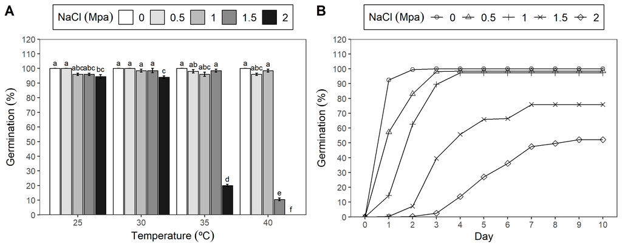

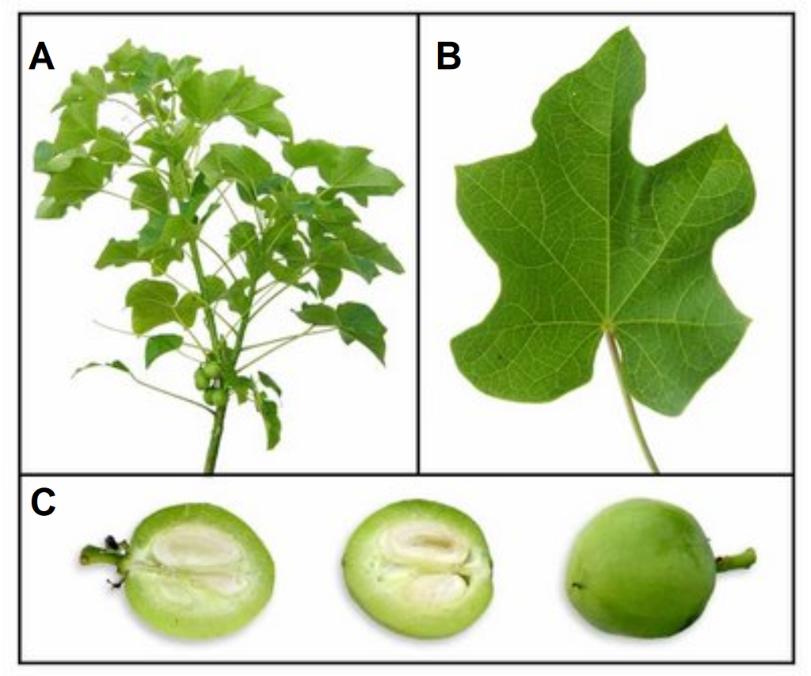

Plant of *Jatropha curcas*. A) Foliage, B) Leaf, C) Fruit.

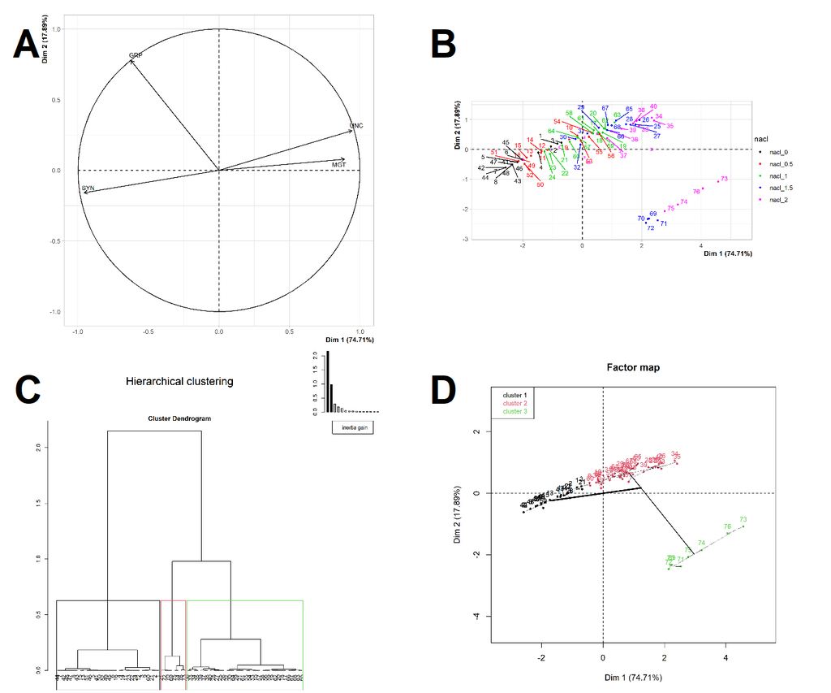

Multivariate Analysis: Principal component Analysis and Hierarchical Clustering Analysis.

# Anexos

[figure not shown]